# **Female Genital Cutting in Guinea**

Final Project

Imane BENSOUDA KORACHI

# **Background**

Female genital mutilation (FGM) comprises all procedures involving partial or total removal of the external female genitalia or other injury to the female genital organs for non-medical reasons.

In Guinea, the practice of FGM is deeply rooted in tradition and culture and it is viewed as a traditional initiation ceremony that marks a girl’s transition into womanhood.

However, FGM is a dangerous practice that holds no health benefits for girls and women and can cause severe complications such as bleeding, complications in childbirth and increased risk of newborn deaths.

This report is based on the findings of the [DHS report (2018)](https://dhsprogram.com/) in Guinea, and will look into the prevalence and opinions of Guinean women on FGM.

# **Prevalence of Circumcision**

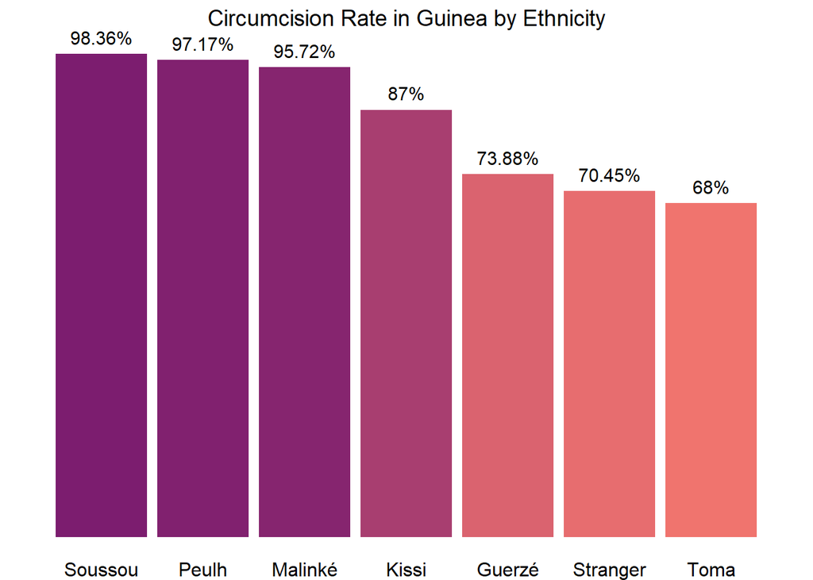

# **Aspects of Circumcision**

## Type of Circumicision

Among the circumcised women aged 15 to 49 years old, about one in two women has had the flesh around their genital area removed.

**Type of circumcision performed in Guinea**

| Type of circumcision | n (%) |
| --- | --- |
| Flesh removed from genital area | 5782 (56.17) |
| Genital area just nicked without removing any flesh | 508 (4.94) |
| Genital area sewn closed | 1079 (10.48) |
| Unknown | 2924 (28.41) |

## Circumciser’s Profession

Circumcision is predominantly performed by traditionional circumcisers. However, there seems to be a shift toward health professionals, as there is an important increase in the number of interventions performed by doctors, trained nurses and midwives among younger girls.

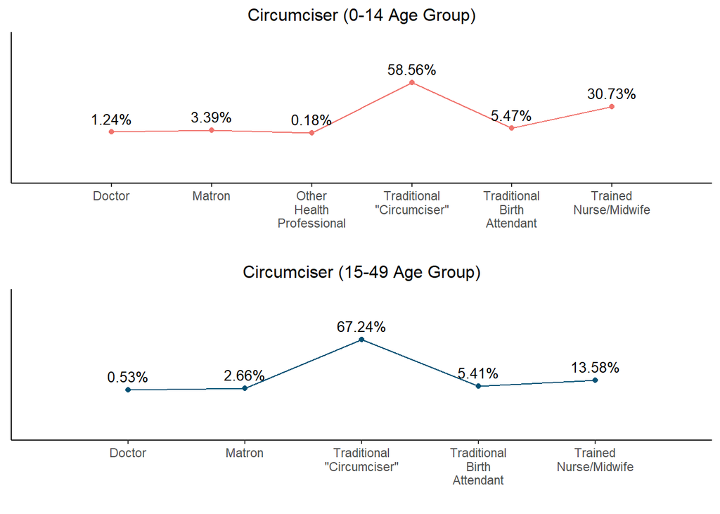

# **Opinions on FGM**

Opinions on circumcision among women vary based on their circumcision status. Circumcised women are more inclined to support the practice, whereas uncircumcised women tend to be in favor of its discontinuation.

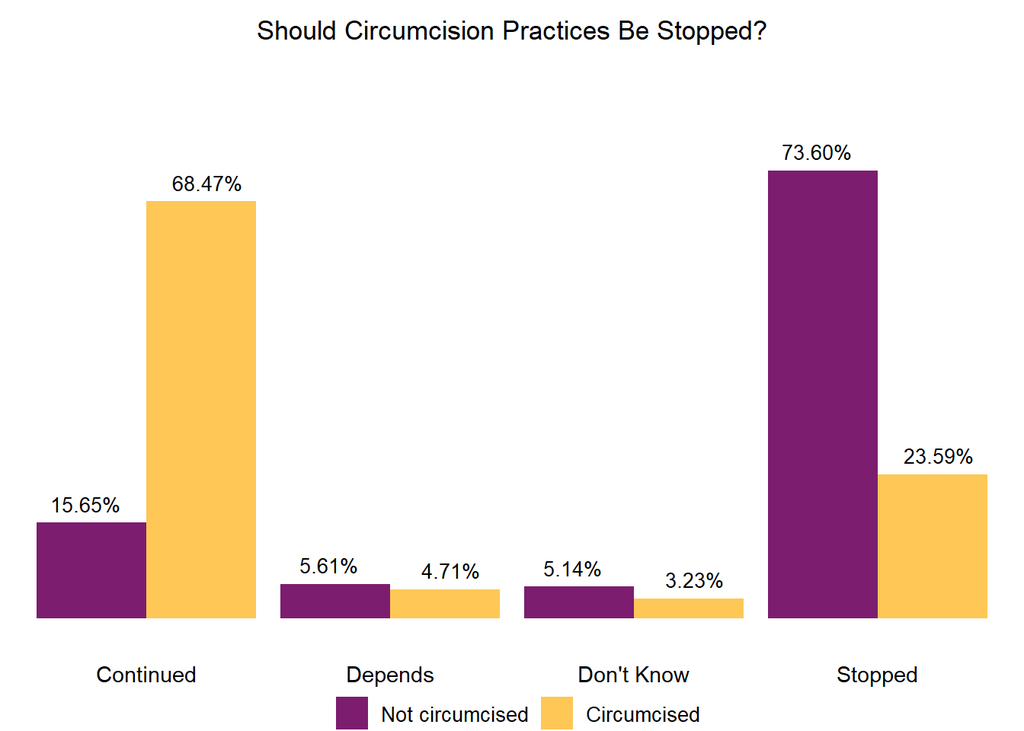

The opinion on circumcision varies by region as well. Faranah and N’Zérékoré regions stand out from the others with higher percentages of women who are in favor of stopping this practice.

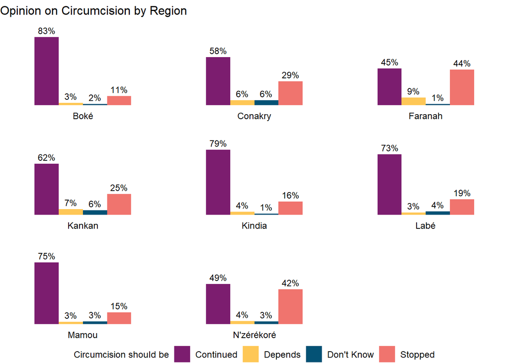

Conservative attitudes towards female circumcision are more prevalent among the Soussou, Peulh, and Malinké communities.

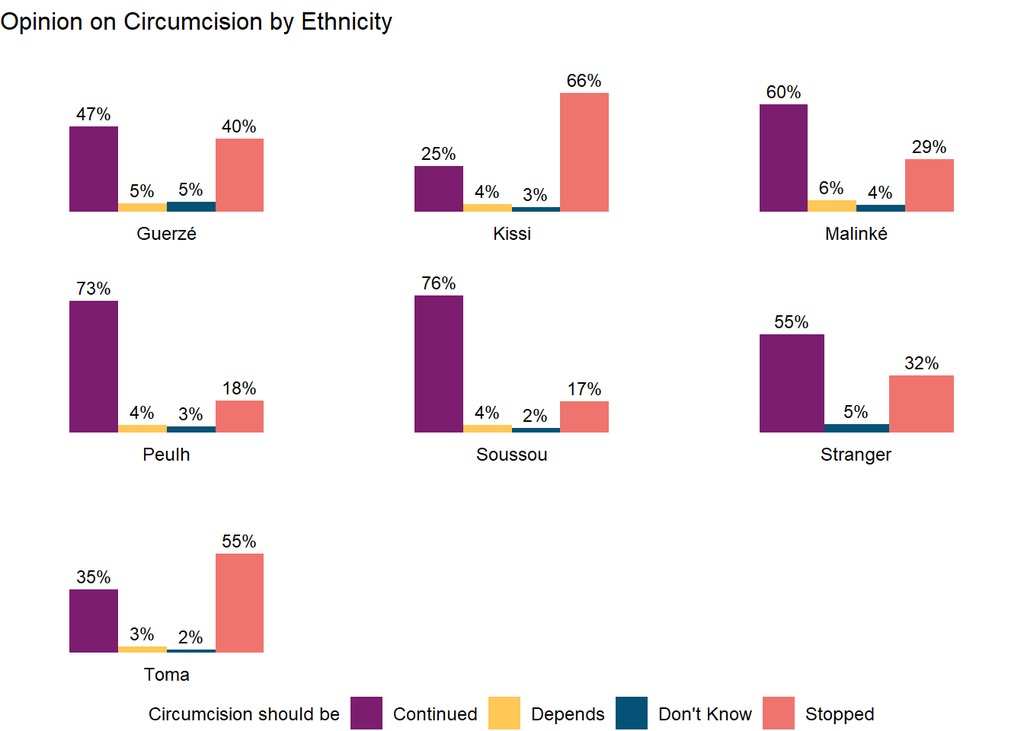

# **Conclusion**

Numerous measures have been taken in Guinea to raise awareness against female genital mutilation. However, despite all these efforts, the practice of female genital mutilation persists, thereby endangering the lives of many women by compromising their sexual and reproductive health.